# Fragile Y Simulation

Heath Blackmon

# **SECTION 1**

# PAR size and fitness

My conception for the way to start this off is to have a simple model where selection occurs in two stages one is based on the adult phenotype and one is based on fidelity of segregation. At this stage we might expect that a small PAR is beneficial since it could allow for sexual antagonism to be mitigated. The plot below shows what we will start with. Here we calculate fitness of the adult strictly as a function of PAR size with zero PAR equal to one and 3Mb equal to .5.

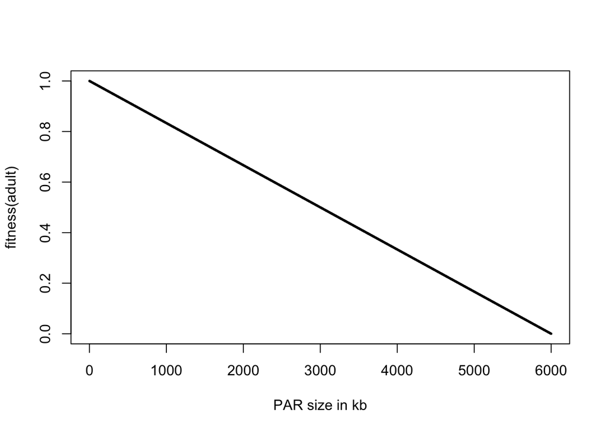

```r
x<- 0:6000
y <- -0.0001666667*x + 1
plot(x,y,cex=.2, xlab="PAR size in kb", ylab="fitness(adult)")
```

# PAR size and aneuploidy

But the PAR size should also effect the risk of aneuploidy assuming an individual lives to reproduce. The function that I am using to determine the probability of aneuploidy is based on a probability of 1 if there is no par and a probability of .06 if there is a human sized PAR. .06 = Turner’s + Klienfelter’s

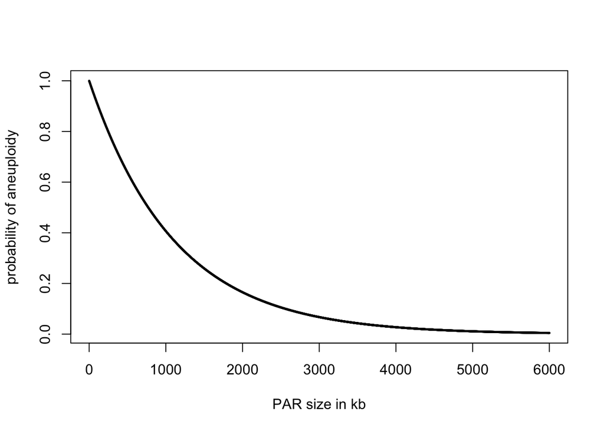

```r
x<- 0:6000
y <- exp(-.0009*x)
plot(x,y,cex=.2, xlab="PAR size in kb", ylab="probability of aneuploidy")
```

So at this very simple point lets run a simulation and see what the outcome will be. Assumptions of this simulation are:

fitness of aneuploids = 0

population size = 1000 and constant

initial par size 3 Mb

par size evolves by brownian motion

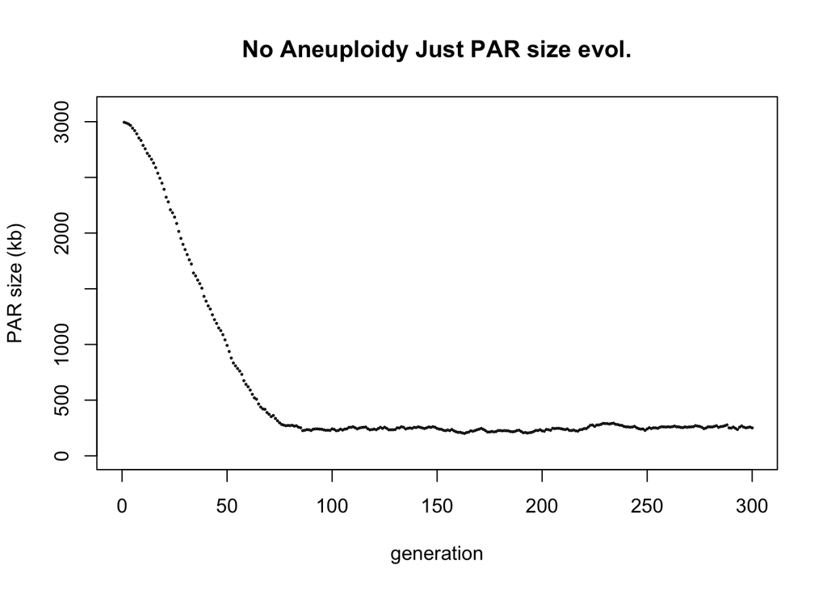

```r
  par.sizes <- vector(mode="numeric", length=1000)
  par.sizes <- rep(3000, 1000)
  fitness <- vector(mode="numeric", length=1000)
  fitness <- rep(1, 1000)
  gens <- 300
  for(i in 1:gens){
    # so here we basically allow par size to mutate by
    # brownian process
    par.sizes <- par.sizes + rnorm(n=1000, mean=0, sd=100)
    par.sizes[par.sizes < 0] <- 0
    # now for the males that have these new par
    # sizes we want to award males that have less
    # par on the grounds that these males can have
    # resolved sexual antagonism
    fitness <- -0.0001666667*par.sizes + 1
    fitness[fitness < 0] <- 0
    # lets have a round of selection on adult males
    # based on this fitness function
    par.sizes <- sample(par.sizes, size = length(par.sizes), prob = fitness, replace=T)
    # now lets plot the results
    if(i == 1) plot(x=i,y=mean(par.sizes), cex=.2, main="No Aneuploidy Just PAR size evol.", xlim=c(0,300),ylim=c(0,3100),xlab="generation", ylab="PAR size (kb)")
    if(i>1) points(x=i,y=mean(par.sizes),cex=.2)
  }
```

OK, so that does what we want we would expect if only force was resolving sexual antagonism we should evolve towards zero PAR size.

# combining PAR size and aneuploidy evolution

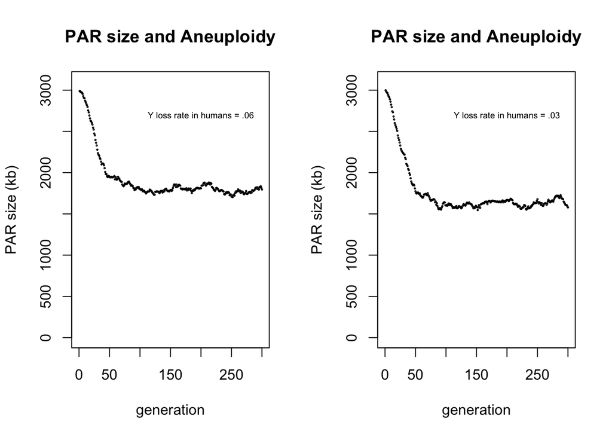

```r
  par(mfcol=c(1,2))
  par.sizes <- vector(mode="numeric", length=1000)
  par.sizes <- rep(3000, 1000)
  fitness <- vector(mode="numeric", length=1000)
  fitness <- rep(1, 1000)
  gens <- 300
  for(i in 1:gens){
    # so here we basically allow par size to mutate by
    # brownian process
    par.sizes <- par.sizes + rnorm(n=length(par.sizes), mean=0, sd=100)
    par.sizes[par.sizes < 0] <- 0
    # now for the males that have these new par
    # sizes we want to award males that have less
    # par on the grounds that these males can have
    # resolved sexual antagonism
    fitness <- -0.0001666667*par.sizes + 1
    fitness[fitness < 0] <- 0
    # lets have a round of selection on adult males
    # based on this fitness function
    par.sizes <- sample(par.sizes, size = 1000, prob = fitness, replace=T)
    # now we add aneuploidy
    aneuploidy.risk <- exp(-.0009*par.sizes)
    par.sizes <- par.sizes[!aneuploidy.risk > runif(n=1000, min=0, max=1)]
    # since we are treating aneuploides as fitness = 0 we can just drop them the
    # population is brought back up to the constant size in line:
    # par.sizes <- sample(par.sizes, size = 1000, prob = fitness, replace=T)
    if(i == 1) plot(x=i,y=mean(par.sizes), cex=.2, main="PAR size and Aneuploidy", xlim=c(0,300),ylim=c(0,3100),xlab="generation", ylab="PAR size (kb)")
    if(i>1) points(x=i,y=mean(par.sizes),cex=.2)
  }
  text(200,2700,labels="Y loss rate in humans = .06", cex=.6)

  par.sizes <- vector(mode="numeric", length=1000)
  par.sizes <- rep(3000, 1000)
  fitness <- vector(mode="numeric", length=1000)
  fitness <- rep(1, 1000)
  gens <- 300
  for(i in 1:gens){
    # so here we basically allow par size to mutate by
    # brownian process
    par.sizes <- par.sizes + rnorm(n=length(par.sizes), mean=0, sd=100)
    par.sizes[par.sizes < 0] <- 0
    # now for the males that have these new par
    # sizes we want to award males that have less
    # par on the grounds that these males can have
    # resolved sexual antagonism
    fitness <- -0.0001666667*par.sizes + 1
    fitness[fitness < 0] <- 0
    # lets have a round of selection on adult males
    # based on this fitness function
    par.sizes <- sample(par.sizes, size = 1000, prob = fitness, replace=T)
    # now we add aneuploidy
    aneuploidy.risk <- exp(-.001168*par.sizes)
    par.sizes <- par.sizes[!aneuploidy.risk > runif(n=1000, min=0, max=1)]
    # since we are treating aneuploides as fitness = 0 we can just drop them the
    # population is brought back up to the constant size in line:
    # par.sizes <- sample(par.sizes, size = 1000, prob = fitness, replace=T)
    if(i == 1) plot(x=i,y=mean(par.sizes), cex=.2, main="PAR size and Aneuploidy", xlim=c(0,300),ylim=c(0,3100),xlab="generation", ylab="PAR size (kb)")
    if(i>1) points(x=i,y=mean(par.sizes),cex=.2)
  }
  text(200,2700,labels="Y loss rate in humans = .03", cex=.6)
```

Beautiful we now get a trade off between aneuploidy and par size. Next step is to somehow make the PAR size evolution more realistic.

# Adding realism to PAR size reductions

In the above simulation every individual has a PAR that grows or shrinks by a small amount each generation. Lets change it to something more realistic where mutations are very rare. In the example below we can see the result of a model where there is only one mutation in the population per a generation. In this model the only mutations possible are reductions in PAR size. We can see that we still get a very similar result as above.

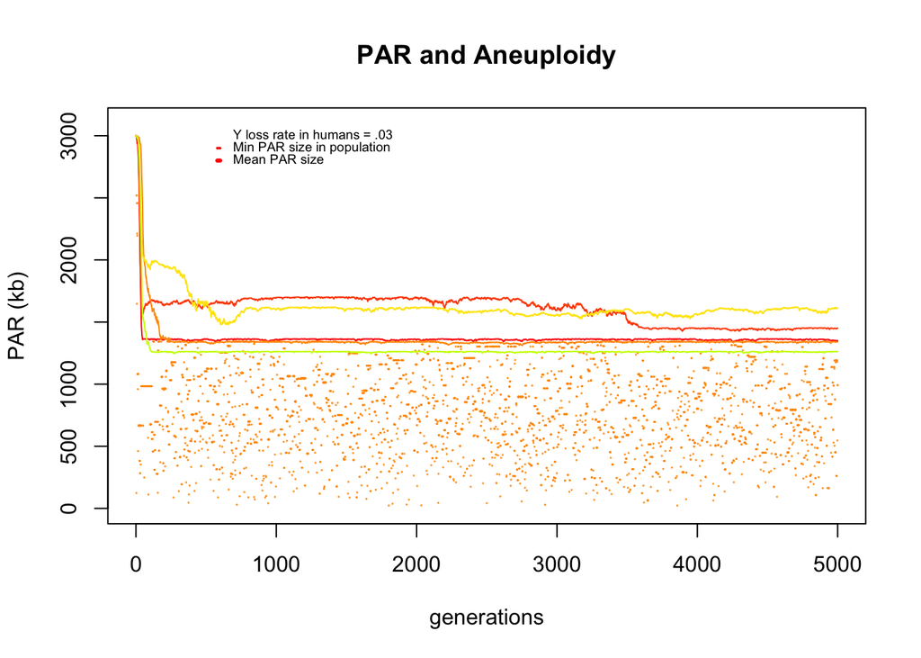

```r
  genotypes <- list()
  colors <- rainbow(20)
  for(k in 1:5){
    par.sizes <- vector(mode="numeric", length=1000)
    par.sizes <- rep(3000, 1000)
    fitness <- vector(mode="numeric", length=1000)
    fitness <- rep(1, 1000)
    gens <- 5000
    mutants.pergen <- 1
    result <- result2 <- vector(mode="numeric", length(gens))
    for(i in 1:gens){
      # make mutants with smaller PARs
      for(j in 1:mutants.pergen){
        mutants <- sample(1:length(par.sizes), size=mutants.pergen)
        par.sizes[mutants] <- par.sizes[mutants] - runif(n=mutants.pergen, min=0, max=max(par.sizes))
      }
      par.sizes[par.sizes < 0] <- 0
      # now for the males that have these new par
      # sizes we want to award males that have less
      # par on the grounds that these males can have
      # resolved sexual antagonism
      fitness <- -0.0001666667*par.sizes + 1
      fitness[fitness < 0] <- 0
      # lets have a round of selection on adult males
      # based on this fitness function
      par.sizes <- sample(par.sizes, size = 1000, prob = fitness, replace=T)
      # now we add aneuploidy
    aneuploidy.risk <- exp(-.001168*par.sizes)
      par.sizes <- par.sizes[!aneuploidy.risk > runif(n=1000, min=0, max=1)]
       # since we are treating aneuploides as fitness = 0 we can just drop them the
      # population is brought back up to the constant size in line:
      # par.sizes <- sample(par.sizes, size = 1000, prob = fitness, replace=T)
      result[i] <- mean(par.sizes)
      result2[i] <- min(par.sizes)
    }
    genotypes[[k]] <- par.sizes
    if(k == 1) plot(x=1:gens,y=result, type="l",
                      lwd=1, main="PAR and Aneuploidy",
                      xlim=c(0,gens),ylim=c(0,3100),
                      xlab="generations", ylab="PAR (kb)", col=colors[k])
    if(k/3 == round(k/3)){
      points(x=1:gens,y=result2, cex=.1, pch=20, col=colors[k])
    }
    if(k>1) points(x=1:gens,y=result, type="l",lwd=1, col=colors[k])

  }
  text(600,3000,labels="Y loss rate in humans = .03", cex=.6, pos=4)

  lines(x=c(580,600), y=c(2800,2800),col="red", lwd=3)
  text(600,2800,labels="Mean PAR size", cex=.6, pos=4)

  points(x=c(580,590,600),y=c(2900,2900,2900), pch=20, col="red", cex=.2)
  text(600,2900,labels="Min PAR size in population", cex=.6, pos=4)
```

I’ve added points to the graph above to indicate the minimum PAR size in the population at each generation. Each color indicates a differnt itteration. What we can see here very clearly is that purifying selection due to aneuploidy (given our aneuploidy function) is sufficient to stop PAR size from getting smaller.

# **SECTION 2**

# Fine tuning the aneuploidy rate based on real data.

Perhaps the best available data for helping to inform model paramters comes from:

*Spriggs, E. L., A. W. Rademaker, and R. H. Martin. “Aneuploidy in human sperm: results of two-and three-color fluorescence in situ hybridization using centromeric probes for chromosomes 1, 12, 15, 18, X, and Y.” Cytogenetic and Genome Research 71, no. 1 (1995): 47-53*

from this we can extract the table below:

failure of meiosis 1 + failure of meiosis 2

```
##      chromosome %disomy
## [1,]          1    0.10
## [2,]         12    0.16
## [3,]         15    0.11
## [4,]         18    0.11
```

failure of meiosis 1

```
##      chromosome % disomy
## [1,] "XY"       "0.15"
```

failure of meiosis 2

```
##      chromosome % disomy
## [1,] "XX"       "0.07"
## [2,] "YY"       "0.21"
```

With autosomes failures at meiosis one and two are confounded however, we might use the failure rates of X chromosomes to properly segregate at meiosis two as a stand-in. If this is true then we could expect meiosis one failure rate for autosomes to be ~ 0.05%. Meanwhile if .15% of sperm are XY (sterile) then another .15% will lack either the X or the Y (essentially inviable) leading to a total of .3% sperm being sterile/inviable due to failures of meiosis 1.

So now lets refit the exponintial function describing risk of aneuploidy with 3 data points now:

can’t find a good equation to fit all the data that i want to use reasons why??

trying to combine biological data from two different processes meiosis 1+2 for 3rd point

meiosis 1 for point 2

and just basic logic for point 1

come back and work later…..

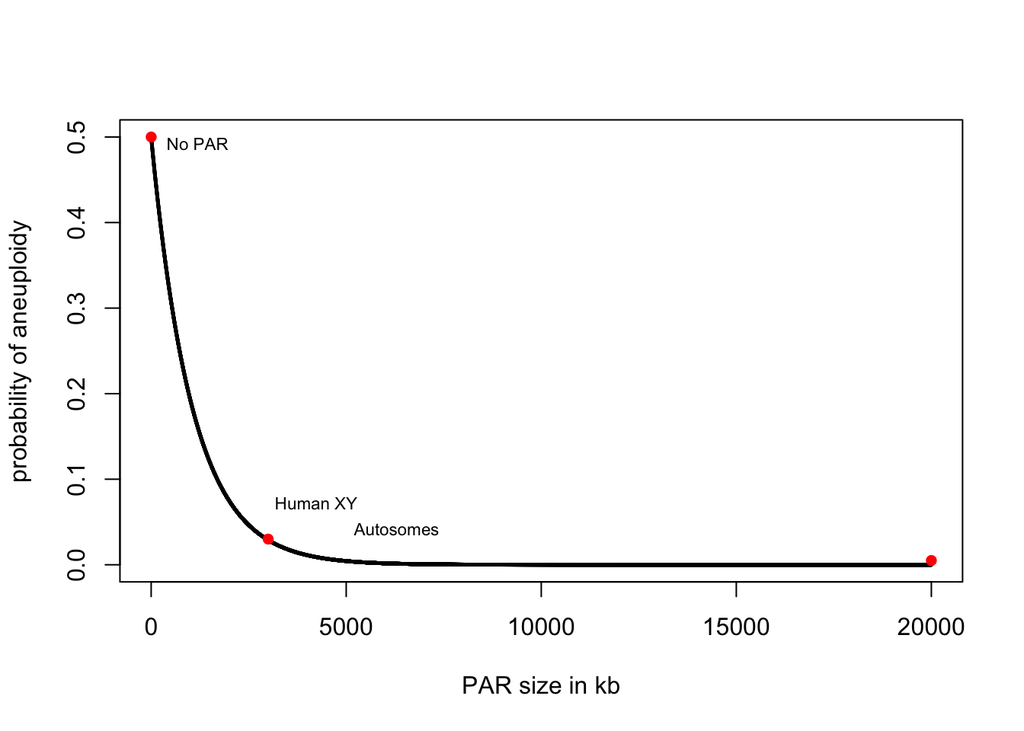

-0.03*log(x) + 0.5

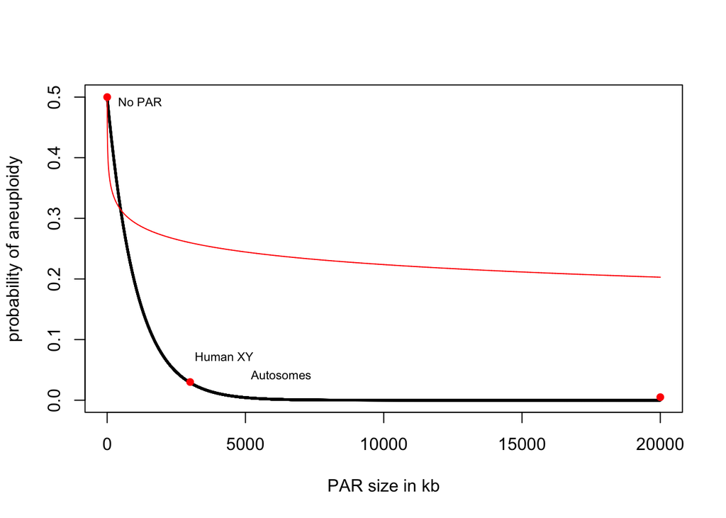

cow = 9000kb dog = 6600kb human = 3000kb horse = 900kb mouse = 700kb

Given this very simpified model of the probability of aneuploidy at meiosis one lets see what strength of selection to reduce recombination leads to an equilibrium par size of 3,000 kb (what we see in humans).

# Predicting aneuploidy rate in other species.

One approach that we could take is to determine the strength of selection to reduce recombination that produces a PAR size that we see in humans. We could then use that model to predict the aneuploidy rate we expect in other species. Obviously this is simplistic but it would provide a nice first approximation.